# Image Analysis and Featurization

Chris Reger

Credit to: J. Gartner, D. Rupp, and F. Burkholder

## Objectives:

1. Describe how images are represented in computers
2. Use `numpy` methods to manipulate images
3. Issues of applying models to images
4. Understand basic feature extraction
5. Manipulate images using the `scikit-image` library

Bonus: Show you a nice example of an image-based capstone, and make the case that figuring out and explaining **why** a machine learning model works can be **more interesting** and **more fun** than just optimizing it to get a good score.

## How are images stored in computers?

Images are saved as a matrix of numbers. Pixels intensities are quantified using various scales. In each scale the higher the number, the more saturated it is.

- `uint8` is an unsigned, 8 bit integer. 2^8 = 256, so `uint8` values go from 0 - 255. In a grayscale image, 0 will be black and 255 white. This is the most common format.
- `uint16` also unsigned, 16 bit. 2^16 = 65536. Twice the memory of a `uint8` value.
- `float` a float value (usually 64 bit) between 0-1. 0 black, 1 white.

[figure not shown]

What do you notice about this image? How is the quality?

[figure not shown]

### What do we change for color images?

Color images are typically 3 equally-sized matrices (rows x columns), where each matrix specifies how much **red**, **blue**, and **green** is present in the image.

[figure not shown]

Color images are stored in *three dimensional* matrices.

- The first dimension is usually the height dimension starting from the *top* of the image.
- The second dimension is usually the width, starting from the left.
- The third dimension is usually the color. This is the "channel" dimension.

For example, the 0th row (the top), the 0th column (the left), and the 0th color (usually red).

Images may sometimes have a fourth channel for transparency ("alpha channel"), or store the colors in an order other than the standard red-green-blue (for example, `OpenCV` uses a blue-green-red ordering for color images).

### Dealing with images in Python

There are several python libraries you can use when working with images in python:

1. **Numpy** - this is a standard way to store and work with the image matrix in python
2. **scikit-image** - included with Anaconda it was developed by the SciPy community. It can be used to do many things we will cover shortly
3. **OpenCV** - there is a Python wrapper of OpenCV which is a C++ library for computer vision. It is a very powerful tool as it has several pretrained models in it and the structure to allow training of your own classical image models.
4. **PIL** and **Pillow** - Pillow is supposed to be a user friendly version of PIL which is the Python Imaging Library. It adds image processing capabilities to Python.

This notebook will use **skimage**. It has very nice [examples](https://scikit-image.org/docs/dev/auto_examples/) and [documentation](https://scikit-image.org/docs/dev/index.html).

## Working with an image

### Loading the Image

```python
coin = io.imread('data/coin.jpg')
```

### What is kind of data is `coin`?

```python
type(coin)
```

```
numpy.ndarray
```

### What are its shape and size?

```python
print(f'Shape : {coin.shape}')
print(f'Size  : {coin.size}')
```

```
Shape : (316, 316, 3)
Size  : 299568
```

This shows that coin is a 316-by-316 pixel image with three channels (red, green, and blue).

### How do we look at the image?

[figure not shown]

```python
io.imshow(coin)
io.show()
```

The above code applies `imshow()` and `show()` functions:

- `imshow()` displays an image
- `show()` displays the pending images queued by `imshow()`

**Take-Away**: *You will need to use* `show()` *when displaying images from non-interactive shells, however it is not necessary for notebooks*

### Manipulating the image with Numpy

Let's try and zoom in on the face.

```
(120, 120, 3)
```

[figure not shown]

```python
face = coin[70:190,120:240,:]  #[rows, columns, channels]
print(face.shape)
io.imshow(face);
```

Now let's set the pixels in the 50th row to "black".

[figure not shown]

```python
coin2 = coin.copy()
coin2[50] = 0
io.imshow(coin2);
```

And let's color an area "green".

[figure not shown]

```python
coin2[148:154, 129:135] = [0, 255, 0]  # [red, green, blue]
io.imshow(coin2);
```

Lets do some boolean indexing!

[figure not shown]

```python
reddish = coin[:, :, 0] < 100 # red channel, values below 100
coin2[reddish] = [255, 0, 0] # Make them Red
io.imshow(coin2);
```

Lastly, lets do a vertical flip.

[figure not shown]

```python
io.imshow(coin2[::-1]);
```

## Image transformations

Often you need to modify the image before working with it, like **resizing** it or **rotating** it.

[figure not shown]

```python
io.imshow(resize(coin, (100,100)));
```

[figure not shown]

```python
io.imshow(rotate(coin, 90));  #skimage to the rescue - try other angles besides 90 degrees
```

## Breakout time

### In your own code-blocks, try each of the following:

- Zoom in on the baby's face
- Perform a horizontal flip
- Rotate 90 degrees
- Make the area between the 50th and 60th row black *(=0)*
- Resize the image to double its size
- Use boolean indexing to make the white areas black

### Let's look at a new image.

```python
sunset = io.imread('data/mich_1.jpg')
```

```
Type  : <class 'numpy.ndarray'>
Shape : (480, 640, 3)
```

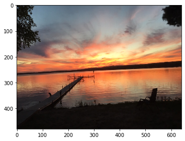

```python
print(f'Type  : {type(sunset)}')
print(f'Shape : {sunset.shape}')
io.imshow(sunset);
```

Let's look at the sunset's top left 100 pixel intensities (10 rows x 10 columns) for the first layer (red).

```python
sunset[:10,:10, 0].reshape(10,10)  # channel 0 is red, 1 is green, 2 is blue
```

```
array([[ 14,   8,  18,  14,  12,  11,  12,  14,  15,  15],
       [ 14,  14,  12,  10,  14,  14,  17,   9,  12,  14],
       [ 17,  16,  13,  14,  16,  10,  15,  17,  17,  15],
       [ 16,  14,  13,  14,  16,  12,  11,  14,  13,  17],
       [ 17,  14,  11,  14,  13,  13,  15,  14,  20,  12],
       [ 38,  17,   7,  35,  31,  10,  13,  14,  10,  26],
       [ 80,  40,  24,  60,  45,   8,   9,  14,  20,  39],
       [ 89,  73,  80,  98,  56,  15,   9,   9,  20,  30],
       [ 64,  82,  83, 102,  93,  50,   9,   1,   9,  23],
       [ 42,  87,  75,  72,  97,  97,  59,  17,   0,  18]], dtype=uint8)
```

### Let's look at the pixel intensities of each of the channels

```python
sunset_red = sunset[:, :, 0]
```

```python
print(f'Shape of sunset_red : {sunset_red.shape}')
print(f'Shape of sunset : {sunset.shape}')
```

```
Shape of sunset_red : (480, 640)
Shape of sunset : (480, 640, 3)
```

Looking at just sunset_red, what do you think we will see?

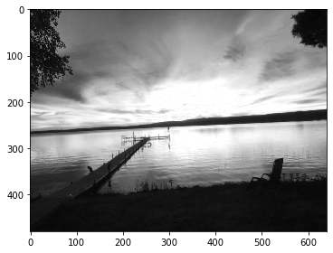

```python
io.imshow(sunset_red);
```

Because there is only one channel, the image is displayed in gray scale. By displaying the pixel intensities for each channel in this way, we can get an idea of how much stauration each channel has.

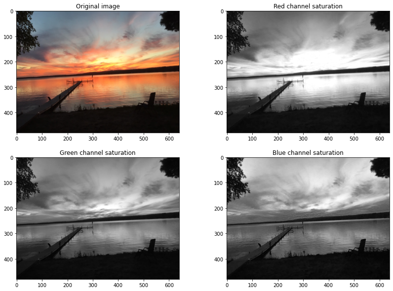

```python
plot_channel_saturations()
```

### Adjusting Exposure Levels

It can be helpful to adjust the exposure. There is a fairly straightforward method to accomplish this.

```python
from skimage import exposure
```

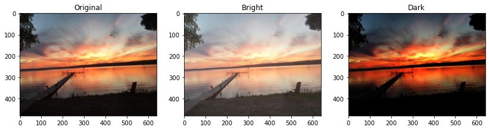

```python
show_exposure_example()
```

### What if we don't care about color in an image?

```python
from skimage.color import rgb2gray
sunset_gray = rgb2gray(sunset)
```

Looking at their shapes:

```python
print("Image shapes:")
print(f"Sunset RGB (3 channel): {sunset.shape}")
print(f"Sunset (gray): {sunset_gray.shape}")
```

```
Image shapes:
Sunset RGB (3 channel): (480, 640, 3)
Sunset (gray): (480, 640)
```

```python
print("\nMinimum and maximum pixel intensities:")
print("Original sunset RGB: ", sunset.min(), ",", sunset.max())
print("Sunset gray (grayscale):", sunset_gray.min(), ",", sunset_gray.max())
```

```
Minimum and maximum pixel intensities:
Original sunset RGB:  0 , 255
Sunset gray (grayscale): 0.005 , 0.9821870588235295
```

And rendering:

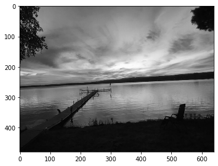

```python
io.imshow(sunset_gray);
```

### A common featurization approach for images: flattening/ raveling

`np.ravel()` can be used to make the image into one long row vector

```python
sunset_gray_values = np.ravel(sunset_gray)
sunset_gray_values.shape
```

```
(307200,)
```

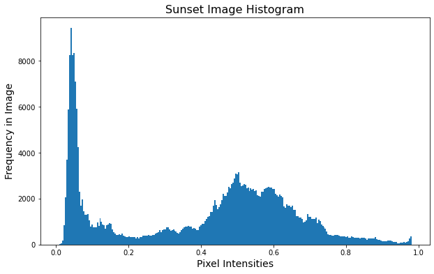

```python
plot_sunset_histogram()
```

Looking at the pixel intensities above, can you think of a way to segment the image that would only show the setting sun?

Try playing with the threshold in your notebooks.

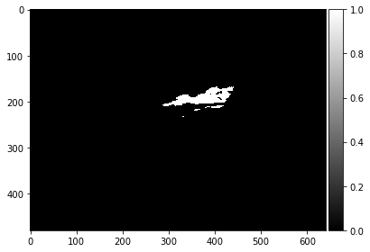

```python
sun_threshold_intensity = 0.9 # play with this
setting_sun = (sunset_gray >= sun_threshold_intensity).astype(int)
io.imshow(setting_sun, cmap='gray');
```

### Featurization: how big was the setting sun in our image?

```python
size_sun_pixels = setting_sun.sum()
print(f'The setting sun was represented by {size_sun_pixels} pixels.')
```

```
The setting sun was represented by 3004 pixels.
```

### Let's look at the coin again

```
(99856,)
```

[figure not shown]

```python
coin_gray = rgb2gray(coin)
coin_gray_values = np.ravel(coin_gray)
print(coin_gray_values.shape)
io.imshow(coin_gray);
```

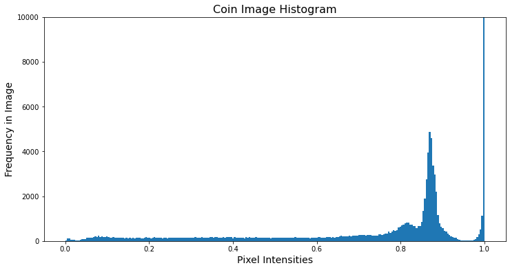

```python
fig = plt.figure(figsize=(12,6))
ax = fig.add_subplot(111)
ax.hist(coin_gray_values, bins=256)
ax.set_xlabel('Pixel Intensities', fontsize=14)
ax.set_ylabel('Frequency in Image', fontsize=14)
ax.set_title("Coin Image Histogram", fontsize=16)
ax.set_ylim([0, 10000]);
```

### Breakout!

- Figure out a way to segment the coin in the image.
- Determine many pixels are used to represent the coin.
- Assuming the radius of the coin is 150 pixels, if the coin was perfectly round, how many pixels would have been expected?
- How close was your answer?

## What are some things we could learn about the image?

If we have a color image how could we find out about aspects of that image?

- We can get the mean of each color in the image to get the mood
- More complex we can use K-means and look at centroids (*we will look at clustering later this week*)
  - KMeans clustering is a common way to extract the dominant colors in an image. [The PyImageSearch blog](https://www.pyimagesearch.com/2014/05/26/opencv-python-k-means-color-clustering/)

#### The average color:

```python
sunset.reshape(-1,3).mean(axis=0)  # the average r,g,b value
```

```
array([124.58139974,  96.41280924,  80.84721354])
```

#### K-means:

```python
from sklearn.cluster import KMeans  # unsupervised learning
```

Fit the model and look at what it accomplishes.

```python
X = sunset.reshape(-1,3)
clf = KMeans(n_clusters=3).fit(X)  # looking for the 3 dominant colors
print(f'Dominant Colors :\n {clf.cluster_centers_}\n')
print(f'Shape of Labels: {clf.labels_.shape}\n')
labels = set(clf.labels_)
print(f'Unique labels: {labels}')
```

```
Dominant Colors :
 [[132.4104405  121.97553384 120.53621752]
 [ 25.36598696  19.28637621  17.25145582]
 [222.74451641 150.79298476 104.73378391]]

Shape of Labels: (307200,)

Unique labels: {0, 1, 2}
```

What does this look like?

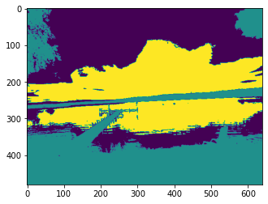

```python
plt.imshow( clf.labels_.reshape(480, 640) );  # color here means nothing, only labels
```

## What does ML data look like?

What does our data typically look like in data science?

|  | feature_1 | feature_2 | feature_3 | feature_4 |
| --- | --- | --- | --- | --- |
| sample_1 | 0 | A | 3.3 | 1 |
| sample_2 | 1 | A | 2.3 | 1 |
| sample_3 | 0 | A | 2.7 | 0 |
| sample_4 | 0 | B | 3.0 | 1 |

### Why is this an issue with images?

- We have to unravel the image to make it flat losing the relationship of surrounding pixels
- Lighting will affect the pixel values (a car will have a very different set of pixel values if it is cloudy vs sunny)
- Humans are very good at finding shapes and using those to classify a image
- You can think of shapes/edges as the difference in adjoining pixels

## Featurization - Looking for edges in images

It *may* help our ML model to give it edges, instead of pixel intensities, to train and predict on.

This is called [edge detection](https://en.wikipedia.org/wiki/Edge_detection) and there are a variety of ways to do it.

A straight-forward approach is to use the gradient (rate of change) of the pixel intensities.

Looking for the direction of "color" change. (We will be using grayscale from here on out).

Looking for the change in gradient for a given pixel to the ones immediately above and below and to the left and right can be described with the following function.

[figure not shown]

Thus giving us

[figure not shown]

With these values we can complete the calculations:

- Magnitude (L2-norm):
  - $ g = \sqrt{g_x^2 + g_y^2}$
- Direction is the arctangent of the ratio of the partial derivatives:
  - $ \theta = arctan(g_y/g_x)$

This process is computationally slow it can be approximated by applying what is called a **convolution** or a vector of the needed form. For the x vector that would be `[-1,0,1]`. Which given the above example will give us the value of `-50`. This is sometimes referred to as edge detection.

### Sobel operator

The convolutions are used to gain information about the pixels surrounding the single pixel. You can slide a convolution over a image and end up with a new image where every pixel now represents numerically the surrounding pixels.  
One of the more well known ones is the Sobel. It has a mathematical make up like below:

[figure not shown]

The magnitude is calculated between these two edge detectors to get the final result.

[figure not shown]

```python
sobel_img = filters.sobel(coin_gray)
io.imshow(sobel_img);
```

We are left with a image that shows the presence of edges as distinct numeric values

```python
sobel_img[0:10,140:150].round(2)
```

```
array([[0.  , 0.  , 0.  , 0.  , 0.  , 0.  , 0.  , 0.  , 0.  , 0.  ],
       [0.45, 0.31, 0.17, 0.09, 0.08, 0.03, 0.06, 0.15, 0.25, 0.33],
       [0.45, 0.54, 0.58, 0.6 , 0.6 , 0.6 , 0.6 , 0.59, 0.54, 0.5 ],
       [0.39, 0.32, 0.25, 0.17, 0.11, 0.08, 0.06, 0.05, 0.02, 0.01],
       [0.03, 0.03, 0.03, 0.03, 0.03, 0.03, 0.04, 0.03, 0.02, 0.02],
       [0.01, 0.01, 0.  , 0.01, 0.01, 0.01, 0.02, 0.02, 0.03, 0.02],
       [0.01, 0.02, 0.02, 0.02, 0.02, 0.02, 0.02, 0.03, 0.02, 0.02],
       [0.01, 0.02, 0.02, 0.02, 0.01, 0.01, 0.02, 0.01, 0.02, 0.01],
       [0.03, 0.02, 0.02, 0.02, 0.03, 0.03, 0.02, 0.01, 0.02, 0.02],
       [0.01, 0.02, 0.02, 0.01, 0.01, 0.  , 0.02, 0.03, 0.03, 0.01]])
```

There are many different filters that have varying mathematics behind them however the idea that we are getting data on the difference of one pixel to another is followed. Getting the difference between the pixels is important as this minimizes the issue of different lighting. Also normalization of images first is usually recommended

```python
from skimage.filters import gaussian
```

[figure not shown]

```python
#Example of a blur filter
io.imshow(gaussian(coin_gray, sigma=3));
```

## Objectives:

1. Describe how images are represented in computers
2. Issues of applying models to images
3. Understand basic feature extraction

### Review

Let's check out an amazing image-based capstone 1: [What the fish?!(betta)](https://github.com/joeshull/what_the_fish_betta)